# IsoGeneGUI: Multiple Approaches for Dose-Response Analysis of Microarray Data Using R

The analysis of transcriptomic experiments with ordered covariates, such as dose-response data, has become a central topic in bioinformatics, in particular in omics studies. Consequently, multiple R packages on CRAN and Bioconductor are designed to analyse microarray data from various perspectives under the assumption of order restriction. We introduce the new R package IsoGene Graphical User Interface (*IsoGeneGUI*), an extension of the original *IsoGene* package that includes methods from most of available R packages designed for the analysis of order restricted microarray data, namely *orQA*, *ORIClust*, *goric* and *ORCME*. The methods included in the new *IsoGeneGUI* range from inference and estimation to model selection and clustering tools. The *IsoGeneGUI* is not only the most complete tool for the analysis of order restricted microarray experiments available in R but also it can be used to analyse other types of dose-response data. The package provides all the methods in a user friendly fashion, so analyses can be implemented by users with limited knowledge of R programming.

Martin Otava (Interuniversity Institute for Biostatistics and Statistical Bioinformatics) , Rudradev Sengupta (Interuniversity Institute for Biostatistics and Statistical Bioinformatics) , Ziv Shkedy (Interuniversity Institute for Biostatistics and Statistical Bioinformatics) , Dan Lin (Interuniversity Institute for Biostatistics and Statistical Bioinformatics) , Setia Pramana (Sekolah Tinggi Ilmu Statistik/Institute of Statistics) , Tobias Verbeke (Open Analytics NV) , Philippe Haldermans (PXL-IT, PXL University College) , Ludwig A. Hothorn (Institute of Biostatistics, Leibniz University Hannover) , Daniel Gerhard (School of Mathematics and Statistics, University of Canterbury) , Rebecca M. Kuiper (Department of Methodology & Statistics, Utrecht University) , Florian Klinglmueller (Section for Medical Statistics, Center for Medical Statistics and Informatics, Medical University of Vienna) , Adetayo Kasim (Wolfson Research Institute for Health and Wellbeing, Durham University)  
2017-05-10

## 1 Introduction

Modelling the dose-response relationship plays an important role in the drug discovery process in the pharmaceutical industry. Typical responses are efficacy or toxicity measures that are modelled with the aim of identifying the dose that is simultaneously efficacious and safe (Pinheiro et al. 2006). The recent development of microarray technology introduced gene expression level as an additional important outcome related to dose. Genes, for which the expression level changes over the dose of the experimental drug, are of interest, since they provide insight into efficacy, toxicity and many other phenotypes. Order restriction is often assumed in the dose-response modelling, usually in terms of monotone trend (Lin et al. 2012b). The restriction is a consequence of the assumption that higher dose levels induce stronger effects in the response (either increasing or decreasing). However, order restriction can also be related to umbrella profiles. In such a case, monotonicity is assumed up to a certain dose level and the direction of the dose-response relationship changes thereafter (Bretz and Hothorn 2003).

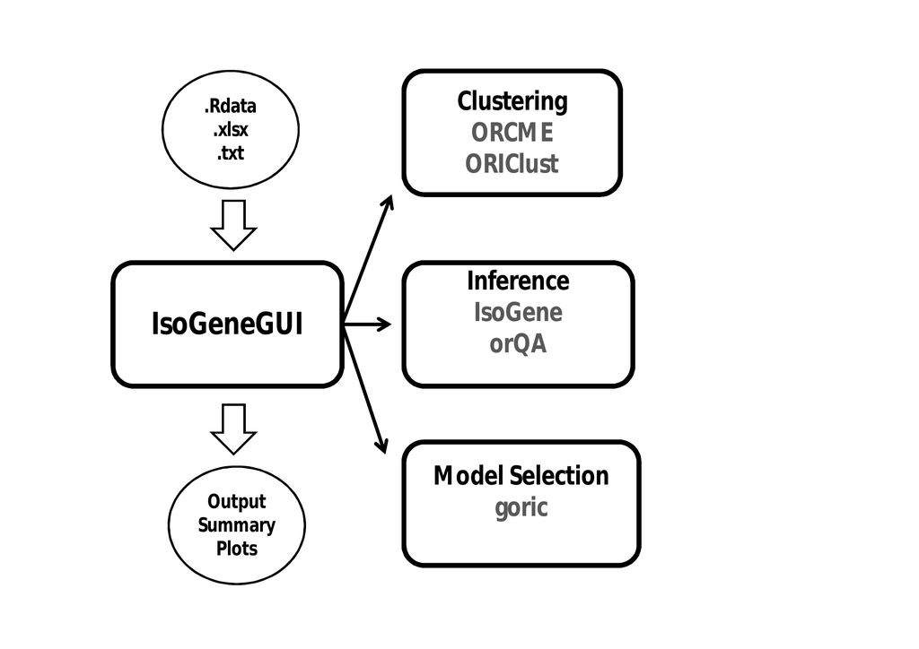

Figure 1: The general structure of the *IsoGeneGUI* package.

Order restricted analysis received a lot of attention in previous years and several R packages were developed for this purpose. Specifically, the R packages [*IsoGene*](https://CRAN.R-project.org/package=IsoGene) ((Lin et al. 2013) and (Pramana et al. 2010)) and [*orQA*](https://CRAN.R-project.org/package=orQA) (Klinglmueller 2010) were developed for inference, [*goric*](https://CRAN.R-project.org/package=goric) ((Gerhard and Kuiper 2012) and (Kuiper and Hoijtink 2013)) for model selection, and [*ORCME*](https://CRAN.R-project.org/package=ORCME) (Kasim et al. 2014) and [*ORIClust*](https://CRAN.R-project.org/package=ORIClust) (Liu et al. 2012) were developed for order restricted clustering of genes.

Inference consists of testing a null hypothesis of a no dose-response relationship, against an ordered alternative. Multiplicity correction needs to be applied due to the large number of tests. The model selection framework quantifies the expected relative distance of a given model to the true underlying model in order to select the best model among a set of candidate models. The model selection approach is basis for the identification of the minimal effective dose or lowest-observed-adverse-effect level (Kuiper et al. 2014). Order restricted clustering is a data analysis approach which aims to form subsets of genes with similar expression profiles. It can be very useful when reference genes are available and the aim of the analysis is to identify genes that behave in a similar way to the reference genes. The clusters can be formed in unsupervised way and the genes that share cluster with reference genes can be identified. Additionally, the resulting clusters can be used to establish potential pathways and gene sets that react to the exposure in close agreement.

All the different methods mentioned above were scattered across multiple specialized packages. The *IsoGeneGUI* package is an envelope package in which all the methods are available together in user friendly framework, allowing to explore the gene expression data set with collection of state-of-the-art tools. The overview of the package structure is schematically shown in Figure 1.

Not all scientists performing microarray experiment analysis are necessarily educated in using R. Hence, the package *IsoGeneGUI* (Pramana et al. 2012) was originally created as a graphical user interface extension of the *IsoGene* package. The large number of *IsoGeneGUI* package downloads from the BioConductor (Gentleman et al. 2004) repository suggests that there is a demand for GUI data analysis tools for inference, model selection, estimation and order restricted clustering. Therefore, the *IsoGeneGUI* package was extended to embrace all currently available tools in one package. In addition to the data analysis tools for estimation, inference, model selection and clustering, the package contains many tools for exporting results, their visualization and easy handling of produced figures. Therefore, *IsoGeneGUI* provides the most complete and simultaneously user friendly data analysis tool, dealing with order restricted microarray experiments and other dose-response studies, that is currently available in R.

The aim of this manuscript is to provide a brief introduction to the package, both the underlying methodological aspects and its particular implementation are discussed. Methods for inference, estimation, clustering and model selection available in *IsoGeneGUI* package are introduced in following section. The structure of the package is described and details about implementation of the methods are given.

## 2 Modelling order-restricted dose-response data

### 2.1 Estimation under order restriction

The methodology described in this section has its roots in the maximum likelihood estimate (MLE) under the order constraints. The MLE is obtained by least squares minimization, with restriction on monotonicity of dose-specific means. The estimation procedure under such condition is called ‘isotonic regression’ (Barlow et al. 1972). It can be shown that the MLE can be obtained using the ‘pool adjacent violators algorithm’ (PAVA). The algorithm first computes the dose-specific means. If there is any violation of the monotonicity between any two estimates of means, it assigns to both of them their weighted average as new estimate for both means. The weights are proportional to the number of observations for particular dose. The procedure is repeated, until all the estimates comply with the monotonicity assumption.

Specifically, assume non-decreasing profile and denote $\mu_0, \ldots, \mu_{K-1}$ the dose-specific means and $n_i$, $i=0, \ldots,K-1$ number of observations per dose level $i$. The unrestricted MLE are equal to the dose-specific sample means denoted by $\hat{\mu}_0, \ldots, \hat{\mu}_{K-1}$. Isotonic means $\hat{\mu}^*_0, \ldots, \hat{\mu}^*_{K-1}$, i.e. the means under the assumption of monotonicity, are computed as $\hat{\mu}^*_j = \hat{\mu}_j$, $j=0,\ldots,K-1$, if the means fulfill $\hat{\mu}_j \leq \hat{\mu}_{j+1}$. If any $\hat{\mu}_j > \hat{\mu}_{j+1}$, then $\hat{\mu}^*_j = \hat{\mu}^*_{j+1} = (n_j \hat{\mu}_j + n_{j+1} \hat{\mu}_{j+1})/(n_j + n_{j+1})$. The procedure is repeated iteratively, until it holds that $\hat{\mu}^*_0 \leq \cdots \leq \hat{\mu}^*_{K-1}$.

### 2.2 Inference

The main goal of the inference framework is to test the relationship between the dose level and the response of interest; gene expression in our case. The primary interest is to test the null hypothesis of no dose effect on the response, given by
$$\label{null}
\begin{array}{l}
H_{0}:\mu_{0} = \mu_{1} = \mu_{2} = \ldots = \mu_{K-1},
\end{array} \tag{1}$$
against an ordered (monotonic) alternative
$$\label{formula:h1up}
\begin{array}{l}
H^{up}:\mu_{0} \le \mu_{1} \le \mu_{2} \le \ldots \le \mu_{K-1},
\end{array}
\;\;\;\;\mbox{or}\;\;\;
\begin{array}{l}
H^{dn}:\mu_{0} \ge \mu_{1} \ge \mu_{2} \ge \ldots \ge \mu_{K-1},\\
\end{array} \tag{2}$$
with at least one strict inequality. Several test statistics for order restricted problems were developed over the last few decades. In the package, the following methods are available: likelihood-ratio test (LRT, (Barlow et al. 1972)), Williams’ test statistic (Williams 1971), Marcus’ statistic (Marcus 1976), M statistic (Hu et al. 2005) and modified M statistic (Lin et al. 2007). The different methods are sensitive to different possible underlying profiles, so there is no overall best method. The choice strongly depends on the context of interest. The LRT test is based on the ratio of a residual sum of squares under monotonicity over a residual sum of squares under the null hypothesis. Williams’ test statistic is based on difference $\hat{\mu}^*_{K-1} - \hat{\mu}_{0}$, i.e. fold change between isotonic mean of last dose and sample mean under first dose. Marcus’ statistics is a modification of Williams’ that compares isotonic means $\hat{\mu}^*_{K-1} - \hat{\mu}^*_{0}$. The M and modified M test statistics are based on the same difference as Marcus’ test, but they differ in a way how the estimation of standard error is approached. Detailed discussion about the methods, their usage and advantages and disadvantages can be found in Lin et al. (2007). The distribution of some of the test statistics cannot be derived analytically. Therefore, resampling based inference is implemented to approximate distribution of test statistics under the null model ((Westfall and Young 1993) and (Ge et al. 2003)).

A common issue in gene expression inference is the presence of genes with relatively low variance that induce large values of the test statistics under consideration, although the magnitude of the effect is negligible. Formally, the genes are declared statistically significant, but from a biological point of view, these genes will not be further investigated due to small fold change. Significance Analysis of Microarrays (SAM, (Tusher et al. 2001)) was proposed as a solution for this issue by inflating the standard error.

### 2.4 Model selection

The task of model selection procedures is to select the ‘best’ model out of the given set of possible models. The ‘best’ is translated into a combination of the likelihood, i.e. how well the model fits the data, and a penalty on the number of parameters (i.e. model complexity). The form of penalty distinguishes various methods developed over past decades. A model selection based method is implemented in the package *goric* using Generalized Order Restricted Information Criterion (GORIC, (Kuiper et al. 2011)). The GORIC method incorporates the information about the order constraints when calculating the information criteria. It extends the ORIC (Anraku 1999) algorithm designed for simple monotone order restriction by allowing more complicated structure of constraints. The set of possible models is given and the output of the GORIC provides weights for each of these models (Kuiper et al. 2014). The weights can be interpreted as posterior model probabilities (Lin et al. 2012a). It is often the case that a null model is not considered in this step, if the method is applied conditionally on the inference step that selected genes with significant dose-response relationship. Based on the model weights, the best model or set of models can be selected. The main motivation for selecting one or more models is to estimate a quantity of interest that characterize dose-response relationship. For example, the determination of the minimum effective dose (MED). The MED is defined as the first dose that exhibits some effect of dose on the response. It can be estimated either based on the best model or as weighted average of several models, with weights proportional to the model weights (Kuiper et al. 2014).

## 3 The structure of the package

The package *IsoGeneGUI* encompasses all the methods mentioned in previous section. The summary is given in Table 1. The GUI was build using `Tcl/Tk` environment.

Table 1: *Packages for the analysis of order-restricted dose-response gene expression data available on CRAN.*

| Package | Analysis type | Reference |
| --- | --- | --- |
| *IsoGene* | Inference | Lin et al. (2012b) |
| *orQA* | Inference | Klinglmueller (2010) |
| *ORCME* | Clustering | Kasim et al. (2014) |
| *ORIClust* | Clustering | Liu et al. (2012) |
| *goric* | Model selection | Gerhard and Kuiper (2012) |

The *IsoGeneGUI* is freely available from R-Forge repository https://r-forge.r-project.org/projects/isogenegui/. It can be downloaded and run from R with commands:

```r
install.packages("IsoGeneGUI", repos = "http://r-forge.r-project.org")
library(IsoGeneGUI)
IsoGeneGUI()
```

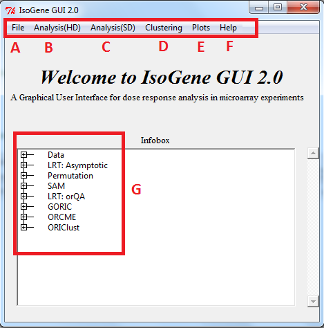

Figure 2: The *IsoGeneGUI* package main menu with highlighted submenus.

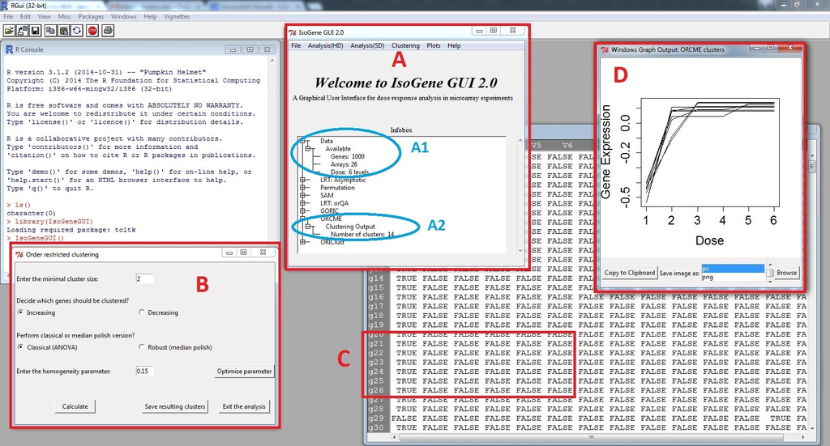

Figure 3: R with opened *IsoGeneGUI* package.

## 4 Applications

### 4.1 Inference

The permutation test is implemented for all five test statistics discussed above, using the functions from *IsoGene* package. For the LRT, a much faster implementation of the permutation test is available from *orQA*. Both methods produce the same result (within the sampling error), so the slower version should be used only in case that additional test statistics are of interest. Additionally, there is an asymptotic solution available for the LRT as well. Note that it is advised to avoid this option in case of small sample sizes.

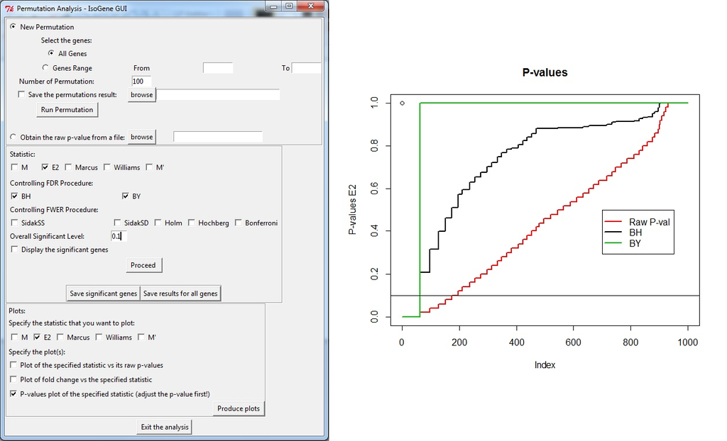

Figure 4: Resampling based inference. Left panel: The window for performing permutation test. Right panel: Plot of an effect of multiplicity adjustment.

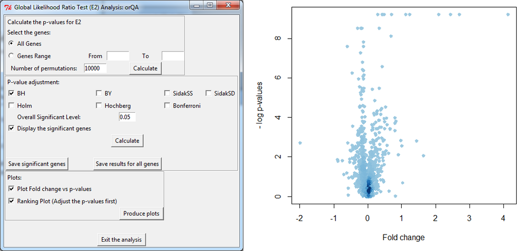

Figure 5: Inference with *orQA*. Left panel: The window for performing LRT. Right panel: Volcano plot.

### 4.2 Clustering

Order restricted clustering is addressed by two algorithms, the $\delta$-clustering from *ORCME* and the ORICC from *ORIClust*. As mentioned above, the package contains two versions of the $\delta$-clustering method: clustering based on the least squares and a robust clustering based on least of absolute residuals. The ORCME window and output is shown in Figure 3. The window implementing ORICC is shown in left panel of Figure 6. All monotone and umbrella profiles are automatically considered and the user cannot influence this setting. However, this setting provides the flexible framework for clustering. The complete profile can be included to the set as well. One or two-stage type of ORICC can be run and output is automatically saved in both text and visual form. The clustering results are shown in right panel of Figure 6 for case in which the top 30 genes are kept for final clustering step.

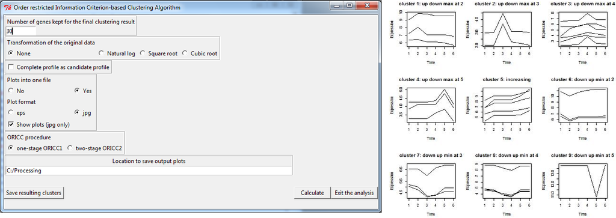

Figure 6: Order restricted clustering using *ORIClust*. Left panel: The window for clustering. Right panel: Plot of all the resulting clusters.

### 4.4 Input and output

The *IsoGeneGUI* package accepts the data sets to be provided either as plain text file, Microsoft Excel spreadsheet or the `.RData` file. The structure of the data set can vary slightly in case of two former file types, but in general, the structure need to be followed where genes are listed in rows and columns represent the different conditions (doses). In case of `.RData`, both microarray results and dose data can be passed at once, as it is done in case of the example data set available in the package.

Similarly, the output of the procedures can be saved either as Excel spreadsheet or as `.RData` file. In general, all the intermediate results can be retrieved, if needed,rather than final result of each procedure only. In addition, the visualization tools mentioned above provides an option to save figures in various formats as well as copy them directly to the clipboard. The goal is to provide the user with option to retrieve most of the relevant results, while emphasizes is put on final results of the procedures that are easily visualized and typically shown on the screen automatically, once the method is finished.

Although the *IsoGeneGUI* package was developed for the analysis of microarray dose-response experiments, it can be used for an analysis of any high dimensional data in a dose-response setting in which the basic data structure is a matrix, given in ((3)), with $n$ variables (or features, the rows of the matrix) and $m$ observations (or conditions, samples, the columns of the matrix).

$$\begin{equation}
\mathbf{X} = \begin{pmatrix}
X_{11} & X_{12} & \dots & X_{1m}\\
X_{21} & X_{22} & \dots & X_{2m}\\
. & . &. & . \\
. & . &. & . \\
. & . &. & . \\
X_{n1} & X_{n2} & \dots & X_{nm}
\end{pmatrix} \tag{3}
\end{equation}$$

In addition, the labeling vector $\boldsymbol{R}$ which links each $j$th sample to a dose related to the sample is given by
$$\label{Rvec}
\boldsymbol{R} = \left (
\begin{array}{llll}
d_{1}, d_{1},\dots, d_{1},& d_{2}, d_{2},\dots, d_{2}, & \dots & d_{K}, d_{K},\dots, d_{K}
\end{array}
\right) \tag{4}$$

In the manuscript, $\boldsymbol{X}$ refers to a gene expression data (as in Section L1000 Dataset) but the package can be used to analyze any high dimensional experiment for which $\boldsymbol{X}$ and $\boldsymbol{R}$ are available. For example, the package can be used for RNA-seq data analysis, after normalization and transformation proposed by Law et al. (2014) for an analysis of RNA-seq using [*limma*](https://CRAN.R-project.org/package=limma). Furthermore, the case that $n=1$, i.e.
$$\label{Xmat1}
\boldsymbol{X} = \left (
\begin{array}{llll}
X_{11} & X_{12} & \dots & X_{1m}\\
\end{array}
\right), \tag{5}$$
corresponds to a setting in which a dose-response experiment was conducted for one variable of interest. Such an experiment can be analyzed using the *IsoGeneGUI* package as well. An example of such an analysis is given in Section Angina Dataset.

### 4.5 L1000 dataset

The L1000 database ([<http://www.lincsproject.org/>](http://www.lincsproject.org/)) is one of the very new microarray datasets, which is of interest to many researchers in this field, nowadays. After analyzing several sources of gene expression data, it was noticed that 1000 carefully selected landmark genes can explain approximately 80% of the information and the dataset produced using this set of genes is known as L1000 dataset. It is essentially a high-throughput gene expression microarray dataset in which cultured cells are treated with various chemical and genetic perturbations and the corresponding transcriptional responses are measured at different concentrations. A computational pipeline is used for data-processing, where raw fluorescence intensity is converted into differential gene expression signatures and the data at each stage of this pipeline are available. The *IsoGeneGUI* package was used for analysis of the gene expression data from level 2 in order to identify statistically significant genes with respect to dose-response profile. Figure 7 shows an example in which the *IsoGeneGUI* package is used to analyse L1000 gene data for a specific compound (BRD-A19037878). All the options available under the tab ‘Analysis(HD)’ can be used for this dataset as well.

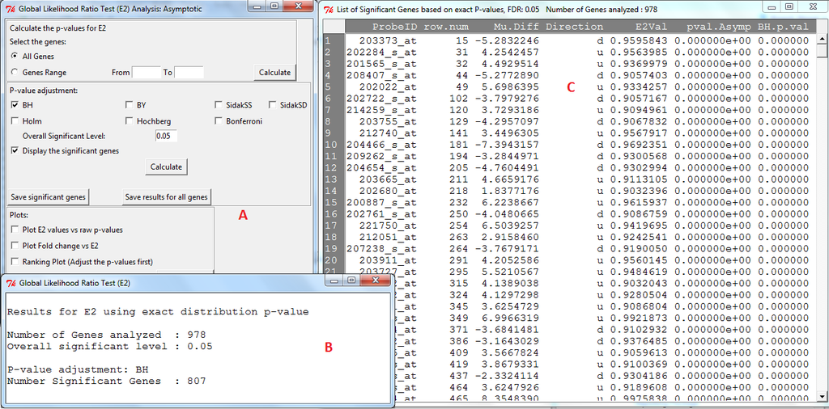

Figure 7: L1000 data. Panel A shows the GUI window for Likelihood Ratio Test. Panel B gives summary of the test results and panel C displays the test results in details.

### 4.6 Angina dataset

This example demonstrates usability of the package on data from a dose-response experiment with a single response variable. The Angina data set ((Westfall et al. 1999), p. 164) represents dose-response study of a drug to treat angina pectoris. The response is the duration (in minutes) of pain-free walking after treatment relative to the values before treatment. Four active doses were used together with a control dose with placebo only. Ten patients per dose were examined. Large values indicate positive effects on patients. The data were used in (Kuiper et al. 2014) and are available under the name `angina` in the package [*mratios*](https://CRAN.R-project.org/package=mratios) (Djira et al. 2012) of the R software. Figure 8 displays the results of the GORIC analysis when this dataset is used. The GORIC window is shown in left panel of Figure 8. The middle plot of Figure 8 displays the data and the model with highest weights, $M_{15}$, increasing in all dose levels. The right panel shows the weights for all the fitted models.

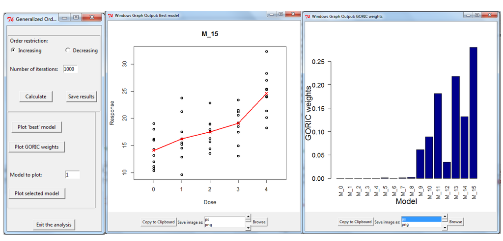

Figure 8: Angina Dataset. The GORIC method when only one sample is available (Angina data). Left panel: The window for providing the inputs required to perform the analysis. Middle panel: Dose-response relationship under model M15. Right panel: GORIC weights for all the models fitted.

## 5 Summary

The analysis of dose-response relationship for order restricted experiments is highly relevant in the drug discovery process. Multiple R packages offer methodology within this framework. The new version of the *IsoGeneGUI* package encompasses a wide range of these packages in a unified way. The package contains data analysis tools for estimation, inference, model selection and clustering. To our knowledge, it is the only software package providing such a wide range of tools simultaneously. Additionally, the GUI implementation of the package allows non-statisticians to conduct the analysis with only minimal knowledge of R.

Although the *IsoGeneGUI* package was developed for the analysis of microarray dose-response experiments, it can be used for an analysis of any high dimensional data in a dose-response setting. For example, for analysis of RNA-seq data, the package can be used after normalization and transformation in same way that it is done by Law et al. (2014). Furthermore, it can be used for the case of single dose-response experiment.

In summary, the *IsoGeneGUI* package is a state-of-the-art collection of methodologies covering a wide range of analyses that are meaningful for order restricted microarray experiments as well as in more general setting of dose-response experiments. Moreover, the package can be used in a straightforward way by the general scientific community.

## 6 Acknowledgement

This work was supported by the Interuniversity Attraction Poles Research Network P7/06 of the Belgian State (Belgian Science Policy) and the Research Project of Hasselt University (BOF11DOC09; to MO).

### 6.1 CRAN packages used

IsoGene, orQA, goric, ORCME, ORIClust, limma, mratios

### 6.2 CRAN Task Views implied by cited packages

Cluster, Omics

K. Anraku. An information criterion for parameters under a simple order restriction. *Biometrika*, 86: 141–152, 1999. URL https://doi.org/10.1093/biomet/86.1.141.

R. E. Barlow, D. J. Bartholomew, M. J. Bremner and H. D. Brunk. *Statistical inference under order restriction.* John Wiley & Sons, 1972.

Y. Benjamini and Y. Hochberg. Controlling the false discovery rate: A practical and powerful approach to multiple testing. *Journal of the Royal Statistical Society B*, 57: 289–300, 1995.

Y. Benjamini and D. Yekutieli. The control of the false discovery rate in multiple testing under dependency. *The Annals of Statistics*, 29(4): 1165–1188, 2001. URL https://doi.org/10.1214/aos/1013699998.

C. E. Bonferroni. Teoria statistica delle classi e calcolo delle probabilità. *Pubblicazioni del R Istituto Superiore di Scienze Economiche e Commerciali di Firenze*, 8: 3–62, 1936.

F. Bretz and L. A. Hothorn. Statistical analysis of monotone or non-monotone dose-response data from *in vitro* toxicological assays. *Alternatives to Lab Animals*, 31(Supplement 1): 81–96, 2003.

Y. Cheng and G. M. Church. Biclustering of expression data. *Proceedings of the Conference on Intelligent Systems for Molecular Biology*, 55: 93–104, 2000.

G. D. Djira, M. Hasler, D. Gerhard and F. Schaarschmidt. *Mratios: Inferences for ratios of coefficients in the general linear model.* 2012. URL http://CRAN.R-project.org/package=mratios.

Y. Ge, S. Dudoit and T. P. Speed. Resampling-based multiple testing for microarray data analysis. *Test*, 12(1): 1–77, 2003. URL https://doi.org/10.1007/bf02595811.

R. C. Gentleman, V. J. Carey, D. M. Bates and et al. Bioconductor: Open software development for computational biology and bioinformatics. *Genome Biology*, 5: R80, 2004. URL https://doi.org/10.1186/gb-2004-5-10-r80.

D. Gerhard and R. M. Kuiper. *goric: Generalized order-restricted information criterion.* 2012. URL http://CRAN.R-project.org/package=goric. R package version 0.0-7.

Y. Hochberg and Y. Benjamini. More powerful procedures for multiple significance testing. *Statistics in Medicine*, 9: 811–818, 1990. URL https://doi.org/10.1002/sim.4780090710.

S. Holm. A simple sequentially rejective multiple test procedure. *Scandinavian Journal of Statistics*, 6: 65–70, 1979.

J. Hu, M. Kapoor, W. Zhang, S. R. Hamilton and K. R. Coombes. Analysis of dose response effects on gene expression data with comparison of two microarray platforms. *Bioinformatics*, 21(17): 3524–3529, 2005. URL https://doi.org/10.1093/bioinformatics/bti592.

A. Kasim, M. Otava and T. Verbeke. *ORCME: Order restricted clustering for microarray experiments.* 2014. URL http://CRAN.R-project.org/package=ORCME. R package version 2.0.

A. Kasim, S. Van Sanden, M. Otava, S. Hochreiter, D.-A. Clevert, W. Talloen and D. Lin. $\delta$-clustering of monotone profiles. In *Modeling dose-response microarray data in early drug development experiments using r*, Eds D. Lin, Z. Shkedy, D. Yekutieli, D. Amaratunga and L. Bijnens pages. 135–149 2012. Springer-Verlag. URL https://doi.org/10.1007/978-3-642-24007-2.

F. Klinglmueller. *orQA: Order restricted assessment of microarray titration experiments.* 2010. URL http://CRAN.R-project.org/package=orQA. R package version 0.2.1.

R. M. Kuiper, D. Gerhard and L. A. Hothorn. Identification of the minimum effective dose for normally distributed endpoints using a model selection approach. *Statistics in Biopharmaceutical Research*, 6(1): 55–66, 2014. URL https://doi.org/10.1080/19466315.2013.847384.

R. M. Kuiper and H. Hoijtink. A Fortran 90 program for the generalization of the order-restricted information criterion. *Journal of Statistical Software*, 54: 1–19, 2013. URL https://doi.org/10.18637/jss.v054.i08.

R. M. Kuiper, H. Hoijtink and M. J. Silvapulle. An Akaike-type information criterion for model selection under inequality constraints. *Biometrika*, 98: 495–501, 2011.

C. W. Law, Y. Chen, W. Shi and G. K. Smyth. Voom: Precision weights unlock linear model analysis tools for RNA-seq read counts. *Genome Biology*, 2014. URL https://doi.org/10.1186/gb-2014-15-2-r29.

D. Lin, S. Pramana, T. Verbeke and M. Otava. *IsoGene: Testing for monotonic relationship between gene expression and doses in a microarray experiment.* 2013. URL http://CRAN.R-project.org/package=IsoGene. R package version 1.0-22.

D. Lin, Z. Shkedy and M. Aerts. Classification of monotone gene profiles using information theory selection methods. In *Modeling dose-response microarray data in early drug development experiments using r*, Eds D. Lin, Z. Shkedy, D. Yekutieli, D. Amaratunga and L. Bijnens pages. 151–164 2012a. Springer-Verlag. URL https://doi.org/10.1007/978-3-642-24007-2.

D. Lin, Z. Shkedy, D. Yekutieli, D. Amaratunga and L. Bijnens, eds. *Modeling dose-response microarray data in early drug development experiments using R - order restricted analysis of microarray data.* Springer-Verlag, 2012b. URL https://doi.org/10.1007/978-3-642-24007-2. ISBN 978-3-642-24006-5.

D. Lin, Z. Shkedy, D. Yekutieli, T. Burzykowki, H. W. H. Göhlmann, A. De Bondt, T. Perera, T. Geerts and L. Bijnens. Testing for trend in dose-response microarray experiments: Comparison of several testing procedures, multiplicity, and resampling-based inference. *Statistical Application in Genetics and Molecular Biology*, 6(1): Article26, 2007. URL https://doi.org/10.2202/1544-6115.1283.

T. Liu, N. Lin, S. Ningzhong and B. Zhang. Information criterion-based clustering with order-restricted candidate profiles in short time-course microarray experiments. *BMC Bioinformatics*, 10: 146, 2009. URL https://doi.org/10.1186/1471-2105-10-146.

T. Liu, N. Lin, N. Shi and B. Zhang. *ORIClust: Order-restricted information criterion-based clustering algorithm.* 2012. URL http://CRAN.R-project.org/package=ORIClust. R package version 1.0-1.

R. Marcus. The powers of some tests of the equality of normal means against an ordered alternative. *Biometrika*, 63: 177–183, 1976. URL https://doi.org/10.2307/2335100.

F. Mosteller and J. W. Tukey. *Data analysis and regression.* Addison-Wesley, 1977.

J. C. Pinheiro, F. Bretz and M. Branson. Analysis of dose response studies: Modeling approaches. In *Dose finding in drug development*, Ed N. Ting pages. 146–171 2006. Springer-Verlag. URL https://doi.org/10.1007/0-387-33706-7.

S. Pramana, D. Lin, P. Haldermans, Z. Shkedy, T. Verbeke, H. W. H. Göhlmann, A. De Bondt, W. Talloen and L. Bijnens. IsoGene: An R package for analyzing dose-response studies in microarray experiments. *The R Journal*, 2(1): 5–12, 2010.

S. Pramana, D. Lin, P. Haldermans and T. Verbeke. *IsoGeneGUI: A graphical user interface to conduct a dose-response analysis of microarray data.* 2012. URL http://www.ibiostat.be/software/IsoGeneGUI/index.html. R package version 1.20.0.

Z. Šidák. On probabilities of rectangles in multivariate student distributions: Their dependence on correlations. *The Annals of Mathematical Statistics*, 42: 169–175, 1971. URL https://doi.org/10.1214/aoms/1177693504.

V. Tusher, R. Tibshirani and G. Chu. Significance analysis of microarrays applied to the ionizing radiation response. *Proceedings of the National Academy of Sciences*, 98: 5116–5121, 2001. URL https://doi.org/10.1073/pnas.091062498.

P. H. Westfall, R. D. Tobias, D. Rom, R. D. Wolfinger and Y. Hochberg. *Multiple comparisons and multiple tests using the SAS system.* SAS Institute Inc., 1999.

P. H. Westfall and S. S. Young. *Resampling-based multiple testing: Examples and methods for p-value adjustment.* John Wiley & Sons, 1993.

D. A. Williams. A test for differences between treatment means when several dose levels are compared with a zero dose control. *Biometrics*, 27: 103–117, 1971. URL https://doi.org/10.2307/2528930.